# Proyecto Final Bioinformática

##### **Análisis de la diversidad genética de *Trypanosoma cruzi***.

###### El *Trypanosoma cruzi* es el agente causal de la enfermedad de Chagas, una enfermedad endémica que afecta principalmente a países de América Latina. Esta enfermedad representa un importante problema de salud pública debido a su alta prevalencia y las graves consecuencias que puede tener en los pacientes infectados crónicamente.

###### Este parásito exhibe una notable diversidad genética, este proyecto busca analizar 24 secuencias del gen HSP70 (Proteína de choque térmico 70), que es importante en la respuesta al estrés y la adaptación del parásito al hospedador y está involucrada en la interacción parásito-hospedador y la modulación de la respuesta inmune.

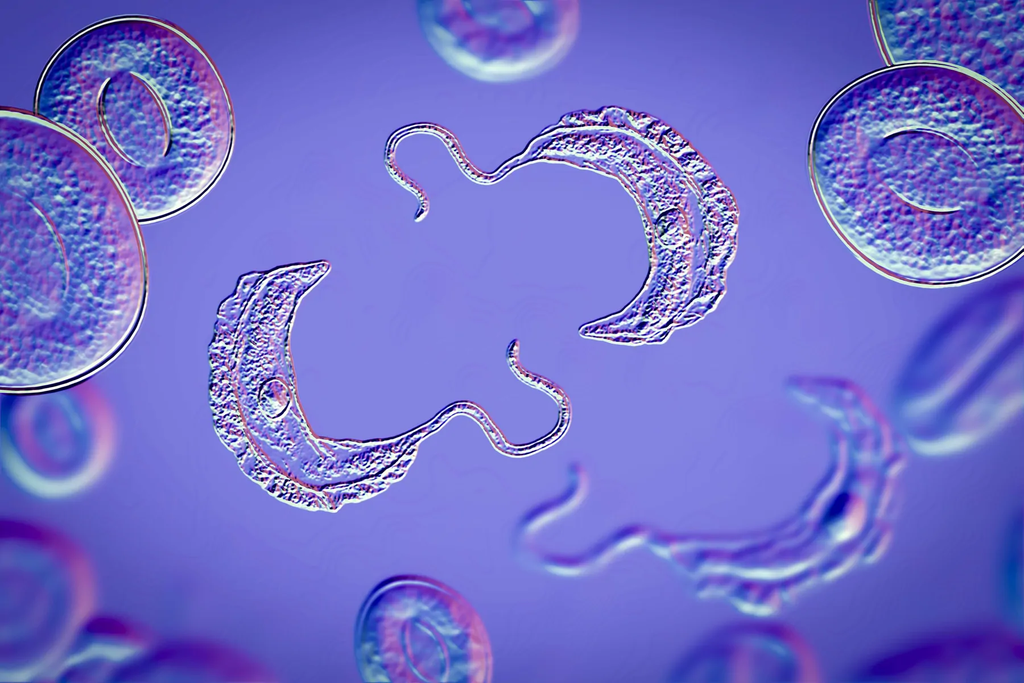

###### La proteína de choque térmico 70 (HSP70) es un componente esencial en la biología de Trypanosoma cruzi, el agente causal de la enfermedad de Chagas. Actúa principalmente como una chaperona molecular, crucial para la supervivencia del parásito en condiciones de estrés. Su importancia radica en su capacidad para facilitar la adaptación del parásito a los cambios drásticos de ambiente que experimenta durante su ciclo de vida, desde el insecto vector hasta el hospedador mamífero.

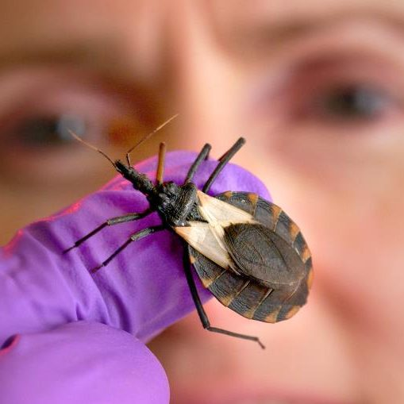

###### En el contexto de la infección, la HSP70 desempeña un papel dual. Por un lado, participa en la adhesión e invasión de las células del hospedador, contribuyendo directamente a la patogénesis. Por otro lado, su presencia en la superficie del parásito la convierte en un objetivo importante para el sistema inmune del hospedador, estimulando la producción de anticuerpos.

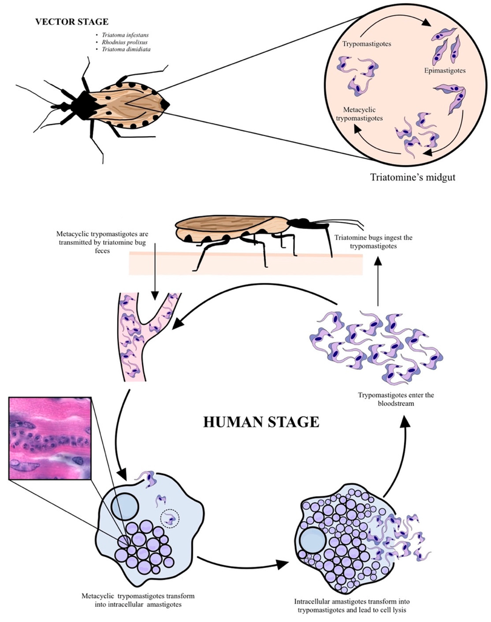

###### La relevancia de la HSP70 se extiende más allá de su función biológica. Su alta conservación entre diferentes cepas la hace útil en estudios filogenéticos, mientras que su inmunogenicidad la convierte en un candidato potencial para el desarrollo de vacunas y métodos diagnósticos. Además, su papel crucial en la supervivencia del parásito la posiciona como un posible blanco para nuevos tratamientos antiparasitarios.

[video not shown]